# Coding question of the day

### Sep 25, 2025

Using the gapminderdataset, calculate the mean fertility rate by region for the year 2015. Which 10 regions had the largest fertility rates that year? Assume there is no missing data. The following steps may be helpful.

1. Filter the data to only include the year 2015
2. Group by region
3. Calculate the average fertility rate for each region
4. Display the top 10 fertility rates (i.e., the 10 largest fertility rates)

```r
library(dslabs)
library(dplyr)
data(gapminder)

gap_2015 <- gapminder %>%
  filter(year == 2015) %>%
  group_by(region) %>%
  summarise(avg_fertility = mean(fertility)) %>%
  arrange(desc(avg_fertility))

gap_2015
```

```
## # A tibble: 22 × 2
##    region          avg_fertility
##    <fct>                   <dbl>
##  1 Middle Africa            4.96
##  2 Western Africa           4.96
##  3 Eastern Africa           4.31
##  4 Polynesia                3.25
##  5 Melanesia                3.10
##  6 Micronesia               3.04
##  7 Southern Africa          2.79
##  8 Northern Africa          2.77
##  9 Central Asia             2.74
## 10 Central America          2.51
## # ℹ 12 more rows
```

### Sep 30, 2025

Using the `gapminder` dataset, for the year 2000, add a column to the dataset called `high_life_exp` that is equal to 1 if the life expectancy is above 70 years of age and 0 otherwise.

How many countries had a life expectancy above 70 years in 2000? What percentage of countries included in this dataset is this?

Hint: it might be helpful to use the `ifelse` function.

```r
library(dslabs)
library(dplyr)
data(gapminder)
```

```r
gapminder_2000 <- gapminder %>%
  filter(year == 2000) %>%
  mutate(high_life_exp = ifelse(life_expectancy > 70, 1, 0))

# Sum the number of countries with life expectancy above 70
sum(gapminder_2000$high_life_exp)
```

```
## [1] 100
```

```r
# Percentage calculation
dim(gapminder_2000) # Show the number of countries in the dataset to get denominator
```

```
## [1] 185  10
```

```r
100/185 # 54%
```

```
## [1] 0.5405405
```

```r
# Another way to do the calculation
sum(gapminder_2000$high_life_exp) / length(gapminder_2000$high_life_exp)
```

```
## [1] 0.5405405
```

### Oct 2, 2025

Using the `gapminder` dataset and `ggplot2`, for the year 1986, plot `fertility` on the x-axis and `life_expectancy` on the y-axis. Color the points according to `continent`, and make the size of the points correspond to the population of the country. Update the x and y axis labels to make them more informative. Hint: the arguments color and size will be useful inside of ggplot. Note: you will most likely get ugly legends - don’t worry about that right now.

```r
library(dslabs)
library(dplyr)
library(ggplot2)
data(gapminder)
```

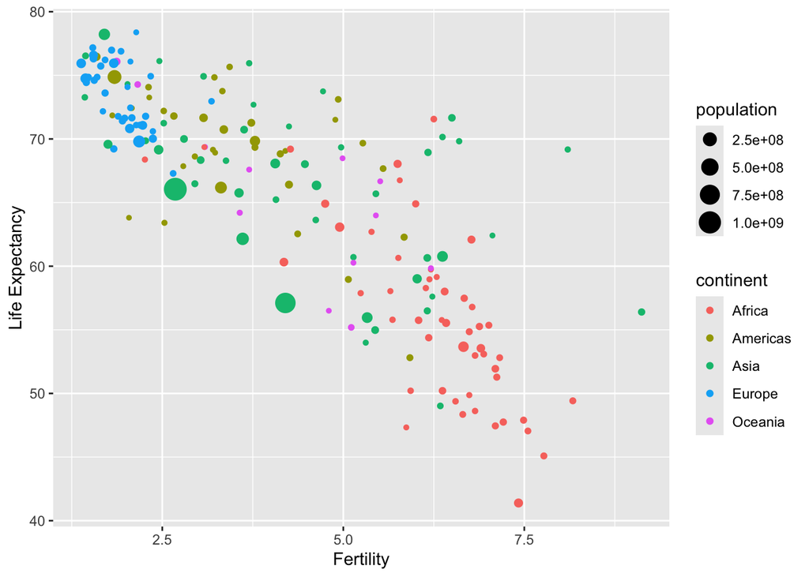

```r
gapminder %>% filter(year == 1986) %>%
  ggplot() +
  geom_point(aes(x = fertility,
                 y = life_expectancy,
                 color = continent,
                 size = population)) +
  xlab("Fertility") +
  ylab("Life Expectancy")
```

### Oct 7, 2025

The `dslabs` package contains the `us_contagious_disease` dataset. This dataset includes weekly reported counts data (cases) for seven diseases from 1928 to 2011 for all 50 US states. Use this dataset and `dplyr` tools to create an object called `data` that stores only the Measles data, includes a per 100,000 people rate, and removes Alaska and Hawaii since they only became states in the late 1950s. Note there is a `weeks_reporting` column - take this into account when calculating the rate. There are 52 weeks in a year.

```r
library(dslabs)
library(dplyr)
data("us_contagious_diseases")

head(us_contagious_diseases)
```

```
##       disease   state year weeks_reporting count population
## 1 Hepatitis A Alabama 1966              50   321    3345787
## 2 Hepatitis A Alabama 1967              49   291    3364130
## 3 Hepatitis A Alabama 1968              52   314    3386068
## 4 Hepatitis A Alabama 1969              49   380    3412450
## 5 Hepatitis A Alabama 1970              51   413    3444165
## 6 Hepatitis A Alabama 1971              51   378    3481798
```

```r
data <- us_contagious_diseases %>%
  filter(disease == "Measles",
         !state %in% c("Alaska", "Hawaii")) %>%
  mutate(rate = ((count/weeks_reporting)*52) / (population/100000))

head(data)
```

```
##   disease   state year weeks_reporting count population      rate
## 1 Measles Alabama 1928              52  8843    2589923 341.43872
## 2 Measles Alabama 1929              49  2959    2619131 119.89333
## 3 Measles Alabama 1930              52  4156    2646248 157.05255
## 4 Measles Alabama 1931              49  8934    2670818 354.98411
## 5 Measles Alabama 1932              41   270    2693027  12.71577
## 6 Measles Alabama 1933              51  1735    2713243  65.19945
```

```r
str(data)
```

```
## 'data.frame':    3675 obs. of  7 variables:
##  $ disease        : Factor w/ 7 levels "Hepatitis A",..: 2 2 2 2 2 2 2 2 2 2 ...
##  $ state          : Factor w/ 51 levels "Alabama","Alaska",..: 1 1 1 1 1 1 1 1 1 1 ...
##  $ year           : num  1928 1929 1930 1931 1932 ...
##  $ weeks_reporting: num  52 49 52 49 41 51 52 49 40 49 ...
##  $ count          : num  8843 2959 4156 8934 270 ...
##  $ population     : num  2589923 2619131 2646248 2670818 2693027 ...
##  $ rate           : num  341.4 119.9 157.1 355 12.7 ...
```

```r
glimpse(data)
```

```
## Rows: 3,675
## Columns: 7
## $ disease         <fct> Measles, Measles, Measles, Measles, Measles, Measles, …
## $ state           <fct> Alabama, Alabama, Alabama, Alabama, Alabama, Alabama, …
## $ year            <dbl> 1928, 1929, 1930, 1931, 1932, 1933, 1934, 1935, 1936, …
## $ weeks_reporting <dbl> 52, 49, 52, 49, 41, 51, 52, 49, 40, 49, 52, 51, 48, 48…
## $ count           <dbl> 8843, 2959, 4156, 8934, 270, 1735, 15849, 7214, 570, 6…
## $ population      <dbl> 2589923, 2619131, 2646248, 2670818, 2693027, 2713243, …
## $ rate            <dbl> 341.43872, 119.89333, 157.05255, 354.98411, 12.71577, …
```

```r
# Another way to do it

data <- us_contagious_diseases %>%
  filter(disease == "Measles",
         state != "Alaska",
         state != "Hawaii") %>%
  mutate(rate = ((count/weeks_reporting)*52) / (population/100000))

head(data)
```

```
##   disease   state year weeks_reporting count population      rate
## 1 Measles Alabama 1928              52  8843    2589923 341.43872
## 2 Measles Alabama 1929              49  2959    2619131 119.89333
## 3 Measles Alabama 1930              52  4156    2646248 157.05255
## 4 Measles Alabama 1931              49  8934    2670818 354.98411
## 5 Measles Alabama 1932              41   270    2693027  12.71577
## 6 Measles Alabama 1933              51  1735    2713243  65.19945
```

```r
str(data)
```

```
## 'data.frame':    3675 obs. of  7 variables:
##  $ disease        : Factor w/ 7 levels "Hepatitis A",..: 2 2 2 2 2 2 2 2 2 2 ...
##  $ state          : Factor w/ 51 levels "Alabama","Alaska",..: 1 1 1 1 1 1 1 1 1 1 ...
##  $ year           : num  1928 1929 1930 1931 1932 ...
##  $ weeks_reporting: num  52 49 52 49 41 51 52 49 40 49 ...
##  $ count          : num  8843 2959 4156 8934 270 ...
##  $ population     : num  2589923 2619131 2646248 2670818 2693027 ...
##  $ rate           : num  341.4 119.9 157.1 355 12.7 ...
```

```r
glimpse(data)
```

```
## Rows: 3,675
## Columns: 7
## $ disease         <fct> Measles, Measles, Measles, Measles, Measles, Measles, …
## $ state           <fct> Alabama, Alabama, Alabama, Alabama, Alabama, Alabama, …
## $ year            <dbl> 1928, 1929, 1930, 1931, 1932, 1933, 1934, 1935, 1936, …
## $ weeks_reporting <dbl> 52, 49, 52, 49, 41, 51, 52, 49, 40, 49, 52, 51, 48, 48…
## $ count           <dbl> 8843, 2959, 4156, 8934, 270, 1735, 15849, 7214, 570, 6…
## $ population      <dbl> 2589923, 2619131, 2646248, 2670818, 2693027, 2713243, …
## $ rate            <dbl> 341.43872, 119.89333, 157.05255, 354.98411, 12.71577, …
```

### Oct 9, 2025

Using the `gapminder` dataset, create a line graph of `life_expectancy` over time for the country Haiti. Make sure to include informative axis labels and a title. There is a substantial decrease in life expectancy one year - look up the reason for this if you don’t know it already. Add text to your plot with `geom_text` indicating the event that happened that year that had such a drastic impact on life expectancy.

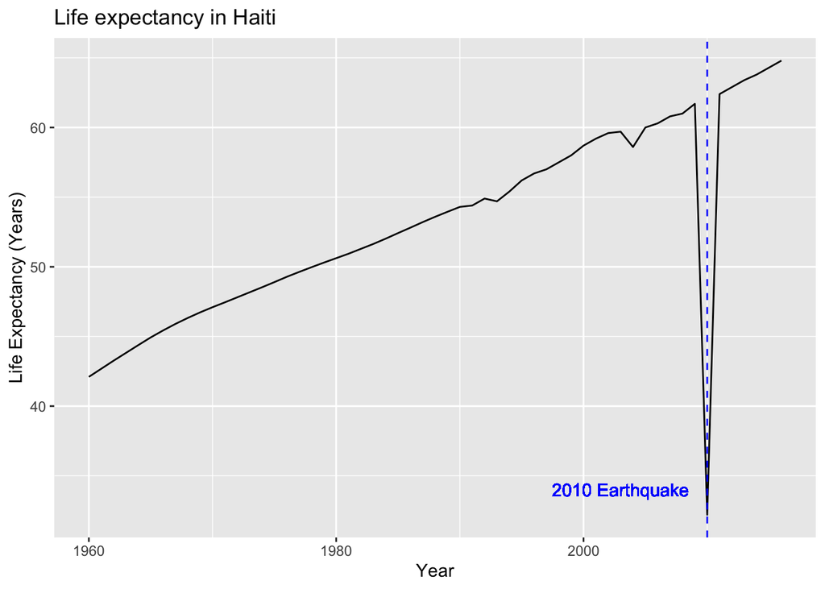

```r
library(dslabs)
library(dplyr)
data("gapminder")

gapminder %>% filter(country == "Haiti") %>%
  ggplot(aes(year, life_expectancy)) +
  geom_line() +
  geom_vline(xintercept = 2010, lty = 2, color = "blue") +
  geom_text(aes(x = 2003, y = 34, label = "2010 Earthquake"), color = "blue") +
  xlab("Year") +
  ylab("Life Expectancy (Years)") +
  ggtitle("Life expectancy in Haiti")
```

### Oct 14, 2025

Using the `murders` dataset from the `dslabs` package and the `state.x77` dataset that is built in to R, make a scatterplot with the total number of gun murders (`total`) on the y-axis and land area in square miles (`Area`) on the x-axis. You will need to use the `left_join` function to join the `state.x77` dataset to the `murders` dataset using the `state` column.

Bonus challenge: are there any NAs in the merged dataset? How are they created?

```r
# Load necessary libraries
library(dplyr)
library(dslabs)
library(ggplot2)
library(tidyr)

# Load the state.x77 dataset and convert to a data frame
data("state")
state_data <- as.data.frame(state.x77)

# Add the state names to the state.x77 dataset
state_data$state <- rownames(state_data)

head(state_data)
```

```
##            Population Income Illiteracy Life Exp Murder HS Grad Frost   Area
## Alabama          3615   3624        2.1    69.05   15.1    41.3    20  50708
## Alaska            365   6315        1.5    69.31   11.3    66.7   152 566432
## Arizona          2212   4530        1.8    70.55    7.8    58.1    15 113417
## Arkansas         2110   3378        1.9    70.66   10.1    39.9    65  51945
## California      21198   5114        1.1    71.71   10.3    62.6    20 156361
## Colorado         2541   4884        0.7    72.06    6.8    63.9   166 103766
##                 state
## Alabama       Alabama
## Alaska         Alaska
## Arizona       Arizona
## Arkansas     Arkansas
## California California
## Colorado     Colorado
```

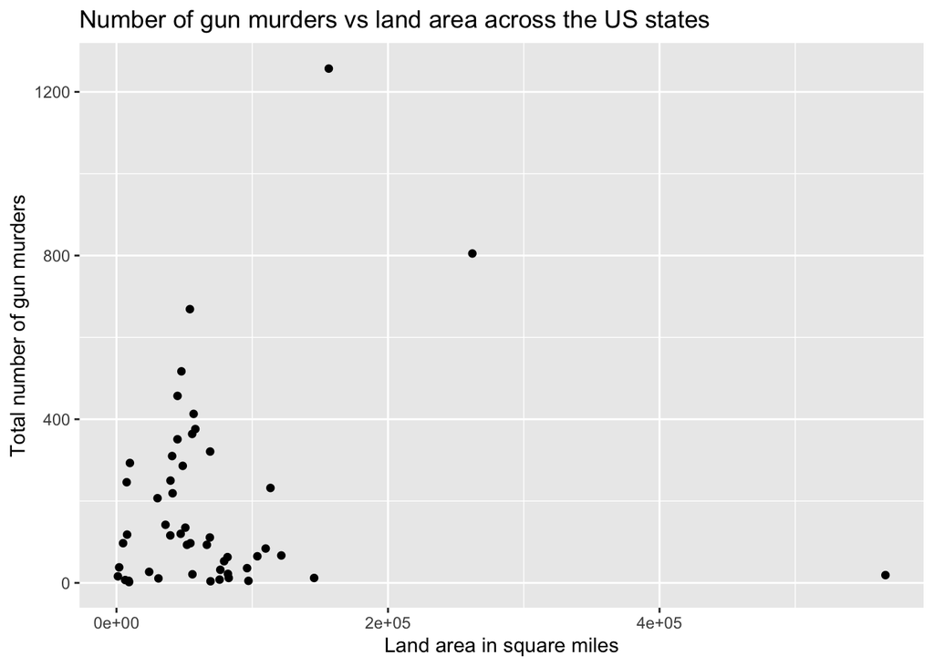

```r
# Load the murders dataset from the dslabs package
data("murders")

# Use the left_join function to join the datasets by the state column
merged_data <- left_join(murders, state_data, by = "state")

# Plot area on x-axis and total number of murders on y-axis
merged_data %>% ggplot(aes(x = Area, y = total)) +
  geom_point() +
  labs(x = "Land area in square miles",
       y = "Total number of gun murders",
       title = "Number of gun murders vs land area across the US states")
```

```r
# Bonus challenge
# Are there any NAs in the merged data set?
sum(is.na(merged_data)) # Yes, there are 8 NAs in the dataset
```

```
## [1] 8
```

```r
# Locate the row with NAs
merged_data[!complete.cases(merged_data),]
```

```
##                  state abb region population total Population Income Illiteracy
## 9 District of Columbia  DC  South     601723    99         NA     NA         NA
##   Life Exp Murder HS Grad Frost Area
## 9       NA     NA      NA    NA   NA
```

All of the NAs are in the District of Columbia row. All of the values from the state.x77 dataset are missing. This means that the state.x77 dataset did not contain a row for District of Columbia, which resulted in NA values when joined to the murders dataset.

### Oct 16, 2025

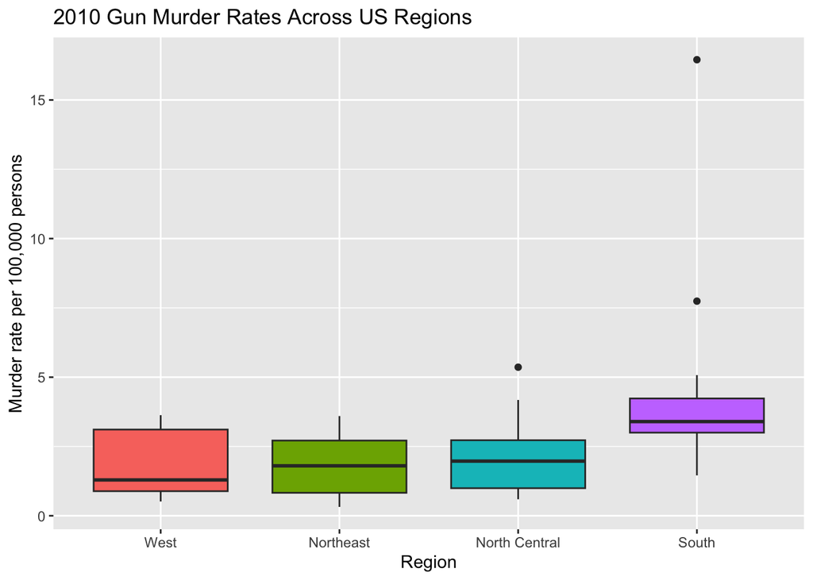

```r
library(dslabs)
library(dplyr)
library(ggplot2)
data("murders")

murders %>%
  mutate(rate = total / population * 100000,
         region = reorder(region, rate, FUN = median)) %>%
  ggplot(aes(region, rate, fill = region)) +
  geom_boxplot() +
  xlab("Region") +
  ylab("Murder rate per 100,000 persons") +
  ggtitle("2010 Gun Murder Rates Across US Regions") +
  guides(fill = "none") # removes legend since not needed here
```

### Oct 21, 2025

Using the `gapminder` dataset, make a line graph of life expectancy over time. Include one line per country, and another line with the global average life expectancy. Be sure to label the global average line and to make it stick out among the country-specific lines. Use the code below to calculate the crude global average for each year.

Hints:

1. Use alpha to help make the global average line stick out.
2. Use 2 geom_line layers.
3. Note that avg is a data frame.

```r
library(dslabs)
library(dplyr)
library(ggplot2)
data("gapminder")

avg <- gapminder %>%
  group_by(year) %>%
  dplyr::summarize(global_avg = mean(life_expectancy, na.rm=TRUE))
print(avg)
```

```
## # A tibble: 57 × 2
##     year global_avg
##    <int>      <dbl>
##  1  1960       54.9
##  2  1961       55.4
##  3  1962       55.8
##  4  1963       56.4
##  5  1964       56.9
##  6  1965       57.3
##  7  1966       57.7
##  8  1967       58.1
##  9  1968       58.5
## 10  1969       58.8
## # ℹ 47 more rows
```

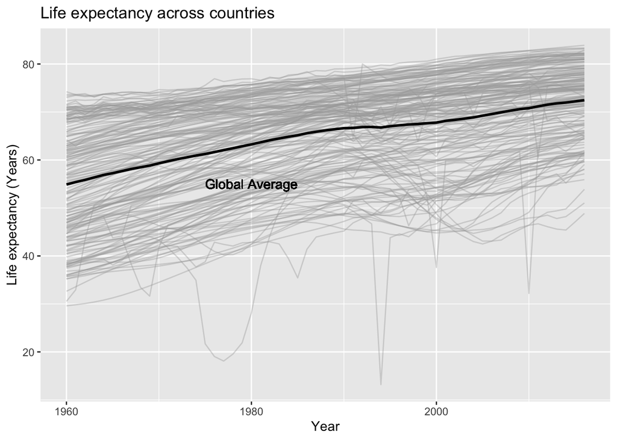

```r
gapminder %>%
  ggplot() +
  geom_line(aes(x = year, y = life_expectancy, group = country),
            color = 'darkgrey',
            alpha = 0.4) +
  geom_line(data = avg,
            mapping = aes(x = year, y = global_avg),
            linewidth = 1) +
  xlab("Year") +
  ylab("Life expectancy (Years)") +
  ggtitle("Life expectancy across countries") +
  #annotate(geom = "text", x = 1970, y = 54,
           #label = "Global average", fontface = "bold")
  geom_text(x = 1980, y = 55, label = "Global Average")
```

```r
gapminder_94 <- gapminder %>% filter(year == "1994")
gapminder_94[which.min(gapminder_94$life_expectancy),] # Rwandan genocide
```

```
##     country year infant_mortality life_expectancy fertility population
## 140  Rwanda 1994            132.3            13.2      6.42    5995987
##           gdp continent         region
## 140 789530666    Africa Eastern Africa
```

```r
gapminder_77 <- gapminder %>% filter(year == "1977")
gapminder_77[which.min(gapminder_77$life_expectancy),] # Cambodian genocide
```

```
##     country year infant_mortality life_expectancy fertility population gdp
## 28 Cambodia 1977            155.4            18.1      5.44    7222050  NA
##    continent             region
## 28      Asia South-Eastern Asia
```

### Oct 23, 2025

Using the `gapminder` dataset, create a categorical life expectancy variable and add it to the `gapminder` dataset. Call this variable `life_expectancy_category` and use the `case_when` function to create it. Life expectancy below 50 should be labeled “Low”, life expectancy greater than or equal to 50 and less than 75 should be labeled “Medium”, and life expectancy greater than or equal to 75 should be labeled “High”.

Now, filter the dataset to only include observations from the year 1999, and create a bar chart of the 3 life expectancy categories. Reorder the bars so that they are in the order Low, Medium, High.

```r
library(dplyr)
library(dslabs)
library(ggplot2)

data("gapminder")
```

```r
gapminder <- gapminder %>%
  filter(year == 1999) %>%
  mutate(life_expectancy_category =
           case_when(
             life_expectancy < 50 ~ "Low",
             life_expectancy >= 75 ~ "High",
             TRUE ~ "Medium"
           )) %>%
  mutate(life_expectancy_category =
           factor(life_expectancy_category,
           levels = c("Low", "Medium", "High")
          )
         )
```

Another (more concise) way to code the above code chunk:

```r
gapminder <- gapminder %>%
  filter(year == 1999) %>%
  mutate(life_expectancy_category =
         factor(case_when(
           life_expectancy < 50 ~ "Low",
           life_expectancy >= 75 ~ "High",
           TRUE ~ "Medium"
         ),
         levels = c("Low", "Medium", "High")))
```

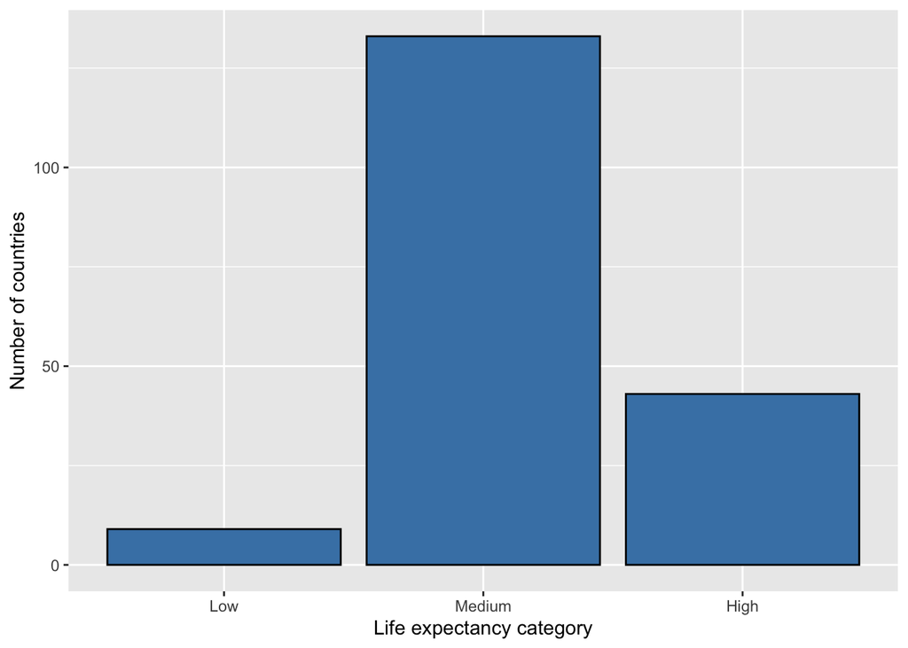

```r
gapminder %>%
  ggplot(aes(life_expectancy_category)) +
  geom_bar(color = "black", fill = "steelblue") +
  labs(x = "Life expectancy category",
       y = "Number of countries")
```

### Oct 30, 2025

Using the `gapminder` dataset, create a new data frame with only the `country`, `year`, `life_expectancy`, and `fertility` columns. Use the `pivot_longer()` function to reshape the dataset so that the `life_expectancy` and fertility columns are combined into a single value column called `value`. The column names should be stored in a new column called `health_indicator`.

```r
library(dslabs)
library(tidyr)
library(dplyr)

data(gapminder)
```

```r
gap_long <- gapminder %>%
  select(country, year, life_expectancy, fertility) %>%
  pivot_longer(cols = c(life_expectancy, fertility),
               names_to = "health_indicator",
               values_to = "value")
head(gap_long)
```

```
## # A tibble: 6 × 4
##   country  year health_indicator value
##   <fct>   <int> <chr>            <dbl>
## 1 Albania  1960 life_expectancy  62.9
## 2 Albania  1960 fertility         6.19
## 3 Algeria  1960 life_expectancy  47.5
## 4 Algeria  1960 fertility         7.65
## 5 Angola   1960 life_expectancy  36.0
## 6 Angola   1960 fertility         7.32
```

### Nov 4, 2025

Read in the data using the code provided. This dataset is currently in wide format. Convert the data frame to long format, with a column named `date` and a column named `cases`. Then, make the date column values into date objects.

Bonus challenge: rename the `Country/Region` column country. Create a new data frame with country name, date, and the total number of cases in the country on each day.

```r
library(readr)
library(dplyr)
library(tidyr)
library(lubridate)

data <- read_csv("https://raw.githubusercontent.com/CSSEGISandData/COVID-19/refs/heads/master/archived_data/archived_time_series/time_series_19-covid-Recovered_archived_0325.csv")
head(data)
```

```
## # A tibble: 6 × 66
##   `Province/State` `Country/Region`   Lat   Long `1/22/20` `1/23/20` `1/24/20`
##   <chr>            <chr>            <dbl>  <dbl>     <dbl>     <dbl>     <dbl>
## 1 <NA>             Thailand         15     101           0         0         0
## 2 <NA>             Japan            36     138           0         0         0
## 3 <NA>             Singapore         1.28  104.          0         0         0
## 4 <NA>             Nepal            28.2    84.2         0         0         0
## 5 <NA>             Malaysia          2.5   112.          0         0         0
## 6 British Columbia Canada           49.3  -123.          0         0         0
## # ℹ 59 more variables: `1/25/20` <dbl>, `1/26/20` <dbl>, `1/27/20` <dbl>,
## #   `1/28/20` <dbl>, `1/29/20` <dbl>, `1/30/20` <dbl>, `1/31/20` <dbl>,
## #   `2/1/20` <dbl>, `2/2/20` <dbl>, `2/3/20` <dbl>, `2/4/20` <dbl>,
## #   `2/5/20` <dbl>, `2/6/20` <dbl>, `2/7/20` <dbl>, `2/8/20` <dbl>,
## #   `2/9/20` <dbl>, `2/10/20` <dbl>, `2/11/20` <dbl>, `2/12/20` <dbl>,
## #   `2/13/20` <dbl>, `2/14/20` <dbl>, `2/15/20` <dbl>, `2/16/20` <dbl>,
## #   `2/17/20` <dbl>, `2/18/20` <dbl>, `2/19/20` <dbl>, `2/20/20` <dbl>, …
```

```r
long_data <- data %>%
  pivot_longer(cols = `1/22/20`:`3/23/20`,
               names_to = "date",
               values_to = "cases") %>%
  mutate(date = mdy(date))

head(long_data)
```

```
## # A tibble: 6 × 6
##   `Province/State` `Country/Region`   Lat  Long date       cases
##   <chr>            <chr>            <dbl> <dbl> <date>     <dbl>
## 1 <NA>             Thailand            15   101 2020-01-22     0
## 2 <NA>             Thailand            15   101 2020-01-23     0
## 3 <NA>             Thailand            15   101 2020-01-24     0
## 4 <NA>             Thailand            15   101 2020-01-25     0
## 5 <NA>             Thailand            15   101 2020-01-26     2
## 6 <NA>             Thailand            15   101 2020-01-27     2
```

```r
data_long_country <- long_data %>%
  rename(country = "Country/Region") %>%
  group_by(country, date) %>%
  dplyr::summarize(cases = sum(cases)) %>%
  ungroup()
head(data_long_country)
```

```
## # A tibble: 6 × 3
##   country     date       cases
##   <chr>       <date>     <dbl>
## 1 Afghanistan 2020-01-22     0
## 2 Afghanistan 2020-01-23     0
## 3 Afghanistan 2020-01-24     0
## 4 Afghanistan 2020-01-25     0
## 5 Afghanistan 2020-01-26     0
## 6 Afghanistan 2020-01-27     0
```

### Nov 6, 2025

The data frame we created on Tuesday (11/4) contains a column called `cases`. The values of this column are the cumulative number of reported cases in a particular country on a particular day. Use the `lag` function to add a new column to the data frame that is the number of new cases for each day. For example, if there were 10 reported cases on January 22nd and 15 reported cases on January 23rd, the number of new cases would be 5 (15-10). Name this column `new_cases`.

Bonus challenge: create a new column that contains the seven-day rolling average of new cases. Name this column `new_cases_7dayavg`. I would suggest using the `rollmean` function from the `zoo` package.

Code from 11/4 question of the day:

```r
library(readr)
library(dplyr)
library(tidyr)
library(lubridate)

data <- read_csv("https://raw.githubusercontent.com/CSSEGISandData/COVID-19/refs/heads/master/archived_data/archived_time_series/time_series_19-covid-Recovered_archived_0325.csv")
head(data)
```

```
## # A tibble: 6 × 66
##   `Province/State` `Country/Region`   Lat   Long `1/22/20` `1/23/20` `1/24/20`
##   <chr>            <chr>            <dbl>  <dbl>     <dbl>     <dbl>     <dbl>
## 1 <NA>             Thailand         15     101           0         0         0
## 2 <NA>             Japan            36     138           0         0         0
## 3 <NA>             Singapore         1.28  104.          0         0         0
## 4 <NA>             Nepal            28.2    84.2         0         0         0
## 5 <NA>             Malaysia          2.5   112.          0         0         0
## 6 British Columbia Canada           49.3  -123.          0         0         0
## # ℹ 59 more variables: `1/25/20` <dbl>, `1/26/20` <dbl>, `1/27/20` <dbl>,
## #   `1/28/20` <dbl>, `1/29/20` <dbl>, `1/30/20` <dbl>, `1/31/20` <dbl>,
## #   `2/1/20` <dbl>, `2/2/20` <dbl>, `2/3/20` <dbl>, `2/4/20` <dbl>,
## #   `2/5/20` <dbl>, `2/6/20` <dbl>, `2/7/20` <dbl>, `2/8/20` <dbl>,
## #   `2/9/20` <dbl>, `2/10/20` <dbl>, `2/11/20` <dbl>, `2/12/20` <dbl>,
## #   `2/13/20` <dbl>, `2/14/20` <dbl>, `2/15/20` <dbl>, `2/16/20` <dbl>,
## #   `2/17/20` <dbl>, `2/18/20` <dbl>, `2/19/20` <dbl>, `2/20/20` <dbl>, …
```

```r
long_data <- data %>%
  pivot_longer(cols = `1/22/20`:`3/23/20`,
               names_to = "date",
               values_to = "cases") %>%
  mutate(date = mdy(date))

head(long_data)
```

```
## # A tibble: 6 × 6
##   `Province/State` `Country/Region`   Lat  Long date       cases
##   <chr>            <chr>            <dbl> <dbl> <date>     <dbl>
## 1 <NA>             Thailand            15   101 2020-01-22     0
## 2 <NA>             Thailand            15   101 2020-01-23     0
## 3 <NA>             Thailand            15   101 2020-01-24     0
## 4 <NA>             Thailand            15   101 2020-01-25     0
## 5 <NA>             Thailand            15   101 2020-01-26     2
## 6 <NA>             Thailand            15   101 2020-01-27     2
```

```r
data_long_country <- long_data %>%
  rename(country = "Country/Region") %>%
  group_by(country, date) %>%
  dplyr::summarize(cases = sum(cases)) %>%
  ungroup()
head(data_long_country)
```

```
## # A tibble: 6 × 3
##   country     date       cases
##   <chr>       <date>     <dbl>
## 1 Afghanistan 2020-01-22     0
## 2 Afghanistan 2020-01-23     0
## 3 Afghanistan 2020-01-24     0
## 4 Afghanistan 2020-01-25     0
## 5 Afghanistan 2020-01-26     0
## 6 Afghanistan 2020-01-27     0
```

New code for today’s question:

```r
library(zoo)

# Calculate new cases
data_long_country <- data_long_country %>%
  group_by(country) %>%
  arrange(date) %>% # Put rows in chronological order
  mutate(new_cases = cases - lag(cases)) %>%
  ungroup()
head(data_long_country)
tail(data_long_country)
```

[output not shown]

```r
# Calculate 7-day rolling average of new cases
data_long_country <- data_long_country %>%
  group_by(country) %>%
  arrange(date, .by_group=TRUE) %>%  # Put rows in chronological order
  mutate(new_cases_7dayavg = rollmean(new_cases, k = 7, fill = NA)) %>%
  ungroup()
head(data_long_country)
```

[output not shown]

```r
library(zoo)

# Calculate new cases
data_long_country <- data_long_country %>%
  group_by(country) %>%
  arrange(date) %>% # Put rows in chronological order
  mutate(new_cases = cases - lag(cases)) %>%
  mutate(new_cases_7dayavg = rollmean(new_cases, k = 7, fill = NA)) %>%
  ungroup()
head(data_long_country)
```

```
## # A tibble: 6 × 5
##   country             date       cases new_cases new_cases_7dayavg
##   <chr>               <date>     <dbl>     <dbl>             <dbl>
## 1 Afghanistan         2020-01-22     0        NA                NA
## 2 Albania             2020-01-22     0        NA                NA
## 3 Algeria             2020-01-22     0        NA                NA
## 4 Andorra             2020-01-22     0        NA                NA
## 5 Angola              2020-01-22     0        NA                NA
## 6 Antigua and Barbuda 2020-01-22     0        NA                NA
```

```r
tail(data_long_country)
```

```
## # A tibble: 6 × 5
##   country    date       cases new_cases new_cases_7dayavg
##   <chr>      <date>     <dbl>     <dbl>             <dbl>
## 1 Uruguay    2020-03-23     0         0                NA
## 2 Uzbekistan 2020-03-23     0         0                NA
## 3 Venezuela  2020-03-23    15         0                NA
## 4 Vietnam    2020-03-23    17         0                NA
## 5 Zambia     2020-03-23     0         0                NA
## 6 Zimbabwe   2020-03-23     0         0                NA
```